# My Beginners Analysis

Denis Motruk

January 17, 2020

To get a better understanding and feel for R and applied statistics as a whole I decided to create my own data analysis project. The Data I will be using can be found here https://www.kaggle.com/russellyates88/suicide-rates-overview-1985-to-2016

## Importing the Data and cleaning

Had to get rid of empty HDI values and their associated rows

```r
suicides <- fread("suicide data.csv")
hdi <- suicides[`HDI for year` != 'NA']

all <- hdi[,lapply(.SD, mean), by=.(country, year, sex),.SDcols = c("suicides/100k pop", "HDI for year", "gdp_per_capita ($)")]
no_null <- all[`suicides/100k pop` != '0']

no_null2 <- no_null %>%
  mutate(female = ifelse(grepl("female", sex), "1", "0"))
```

## Modelling Suicide Rates

I need to be careful however, since there exists a relationships between HDI and GDP per capita.

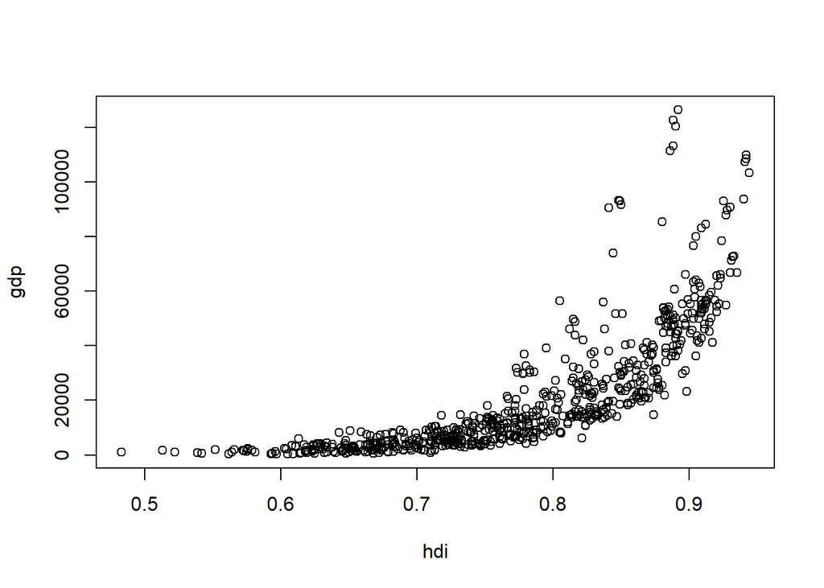

```r
rate <- no_null2$`suicides/100k pop`
hdi <- no_null2$`HDI for year`
gdp <- no_null2$`gdp_per_capita ($)`
sex <- no_null2$female

plot(hdi, gdp)
```

To deal with this I split the model to see individual effects

## Rate modelled by HDI

```r
mdl <- lm(log(rate)~hdi)
summary(mdl)
```

```
##
## Call:
## lm(formula = log(rate) ~ hdi)
##
## Residuals:
##     Min      1Q  Median      3Q     Max
## -4.3008 -0.6722  0.1088  0.8103  2.6875
##
## Coefficients:
##             Estimate Std. Error t value Pr(>|t|)
## (Intercept)   0.1683     0.2559   0.658    0.511
## hdi           2.3370     0.3265   7.157 1.35e-12 ***
## ---
## Signif. codes:  0 '***' 0.001 '**' 0.01 '*' 0.05 '.' 0.1 ' ' 1
##
## Residual standard error: 1.129 on 1339 degrees of freedom
## Multiple R-squared:  0.03685,    Adjusted R-squared:  0.03613
## F-statistic: 51.23 on 1 and 1339 DF,  p-value: 1.35e-12
```

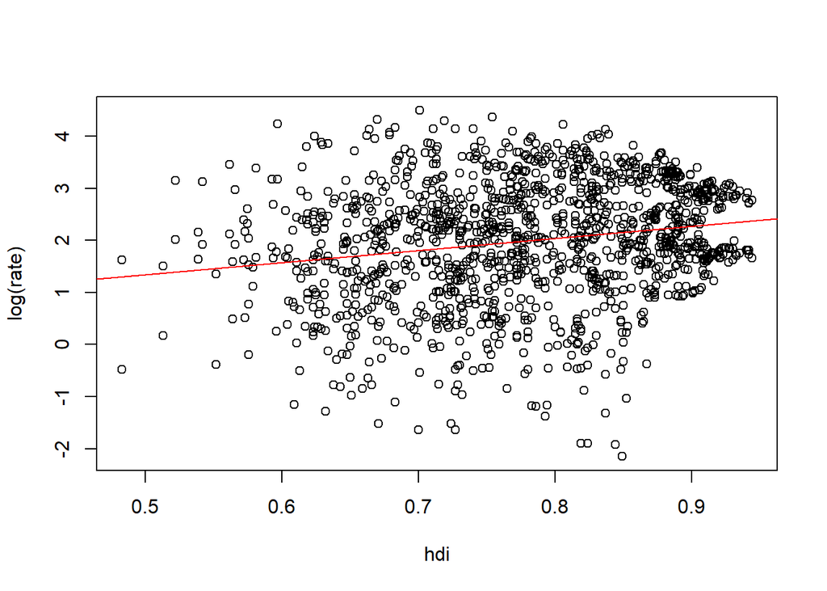

```r
plot(hdi, log(rate))
abline(mdl, col='red', pch=19)
```

We can see that there is a slight relationship with HDI and Suicide rates in the world

## Rate modelled by GDP

```r
mdl2 <- lm(log(rate)~gdp)
summary(mdl2)
```

```
##
## Call:
## lm(formula = log(rate) ~ gdp)
##
## Residuals:
##     Min      1Q  Median      3Q     Max
## -4.3554 -0.6797  0.0922  0.8442  2.5667
##
## Coefficients:
##              Estimate Std. Error t value Pr(>|t|)
## (Intercept) 1.920e+00  4.298e-02   44.67   <2e-16 ***
## gdp         3.081e-06  1.369e-06    2.25   0.0246 *
## ---
## Signif. codes:  0 '***' 0.001 '**' 0.01 '*' 0.05 '.' 0.1 ' ' 1
##
## Residual standard error: 1.148 on 1339 degrees of freedom
## Multiple R-squared:  0.003767,   Adjusted R-squared:  0.003023
## F-statistic: 5.064 on 1 and 1339 DF,  p-value: 0.02459
```

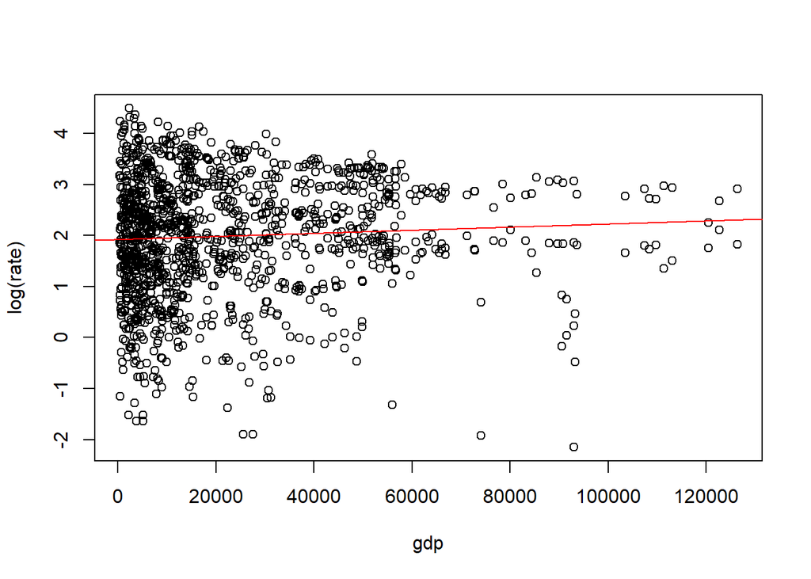

```r
plot(gdp, log(rate))
abline(mdl2, col='red', pch=19)
```

As we can see GDP per capita also has a relationship with Suicide rates

## Compare means of the different year chunks

I had to apply a log transformation to better satisfy the assumptions of a linear model

```r
yrs1 <- subset(no_null2, format(as.numeric(year))<=2000)
yrs2 <- subset(no_null2, format(as.numeric(year))>2000)


y1rate <- yrs1$`suicides/100k pop`
y1hdi <- yrs1$`HDI for year`


yr1model <- lm(log(y1rate) ~ (y1hdi))
summary(yr1model)
```

```
##
## Call:
## lm(formula = log(y1rate) ~ (y1hdi))
##
## Residuals:
##     Min      1Q  Median      3Q     Max
## -3.6984 -0.7197  0.1127  0.7289  2.5158
##
## Coefficients:
##             Estimate Std. Error t value Pr(>|t|)
## (Intercept)  -0.2098     0.4175  -0.502    0.616
## y1hdi         3.2354     0.5660   5.717 2.01e-08 ***
## ---
## Signif. codes:  0 '***' 0.001 '**' 0.01 '*' 0.05 '.' 0.1 ' ' 1
##
## Residual standard error: 1.099 on 440 degrees of freedom
## Multiple R-squared:  0.06913,    Adjusted R-squared:  0.06702
## F-statistic: 32.68 on 1 and 440 DF,  p-value: 2.009e-08
```

```r
y2rate <- yrs2$`suicides/100k pop`
y2hdi <- yrs2$`HDI for year`

yr2model <- lm(log(y2rate) ~ (y2hdi))
summary(yr2model)
```

```
##
## Call:
## lm(formula = log(y2rate) ~ (y2hdi))
##
## Residuals:
##     Min      1Q  Median      3Q     Max
## -4.1997 -0.6583  0.0904  0.7857  2.6408
##
## Coefficients:
##             Estimate Std. Error t value Pr(>|t|)
## (Intercept)  -0.5705     0.3449  -1.654   0.0985 .
## y2hdi         3.0881     0.4283   7.210 1.19e-12 ***
## ---
## Signif. codes:  0 '***' 0.001 '**' 0.01 '*' 0.05 '.' 0.1 ' ' 1
##
## Residual standard error: 1.116 on 897 degrees of freedom
## Multiple R-squared:  0.05478,    Adjusted R-squared:  0.05372
## F-statistic: 51.98 on 1 and 897 DF,  p-value: 1.189e-12
```

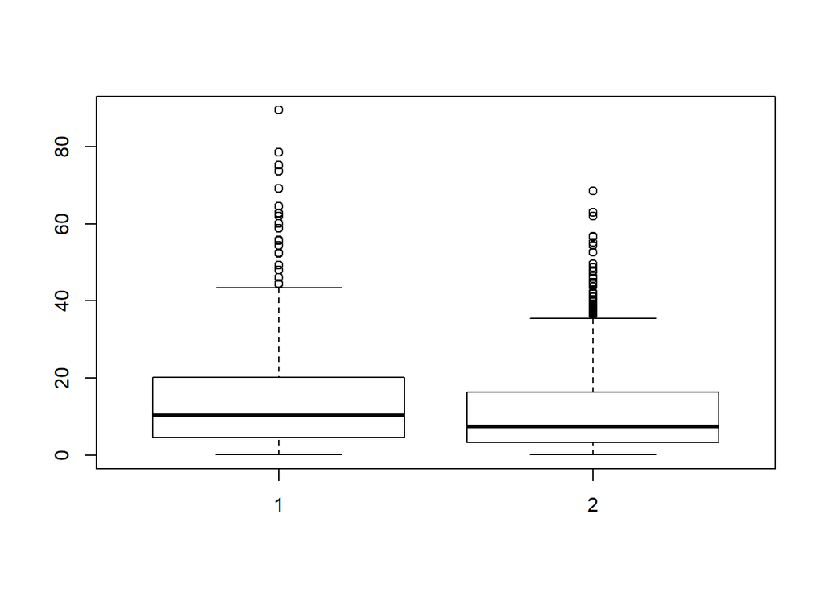

```r
boxplot(y1rate, y2rate)
```

```r
t.test(y1rate, y2rate)
```

```
##
##  Welch Two Sample t-test
##
## data:  y1rate and y2rate
## t = 4.0339, df = 711.2, p-value = 6.079e-05
## alternative hypothesis: true difference in means is not equal to 0
## 95 percent confidence interval:
##  1.642229 4.756464
## sample estimates:
## mean of x mean of y
##  14.61072  11.41137
```

## Conclusions

Barring me having done something terribly wrong, I believe it makes sense that neither of these varibales happen to predict suicide rates well. As we often see, there are many factors that going into such a decision. However, these findings help us identify populations of people who may be at higher risk and thus preventitive measures can be taken.

# Next Steps

Investigate how HDI effects suicide rates in wealthy vs poor countries

# Note

This is by no means a comprehensive study. Out of all my research I found this to provide the most insight into the data so far. I plan to expand this page and its findings as I learn more.